# Regresi Spasial P1

# Pengolahan Data Spasial

Dalam pengolahan data spasial, terdapat dua bentuk utama representasi data yang paling banyak digunakan, yaitu data vektor dan data raster

## Vektor

Data spasial **vektor** merepresentasikan fenomena di permukaan bumi dengan menggunakan **titik (point)**, **garis (line)**, dan **poligon (polygon)**.

- **Titik** digunakan untuk objek yang hanya memiliki posisi, misalnya lokasi sumur, pohon, atau rumah sakit.
- **Garis** digunakan untuk objek yang memiliki panjang, misalnya jalan, sungai, atau jaringan listrik.
- **Poligon** digunakan untuk objek yang memiliki luas, misalnya batas desa, area hutan, atau danau.

```r
data(meuse)
meuse <- st_as_sf(meuse, coords = c("x", "y"), crs = 28992)
coord <- st_coordinates(meuse)
```

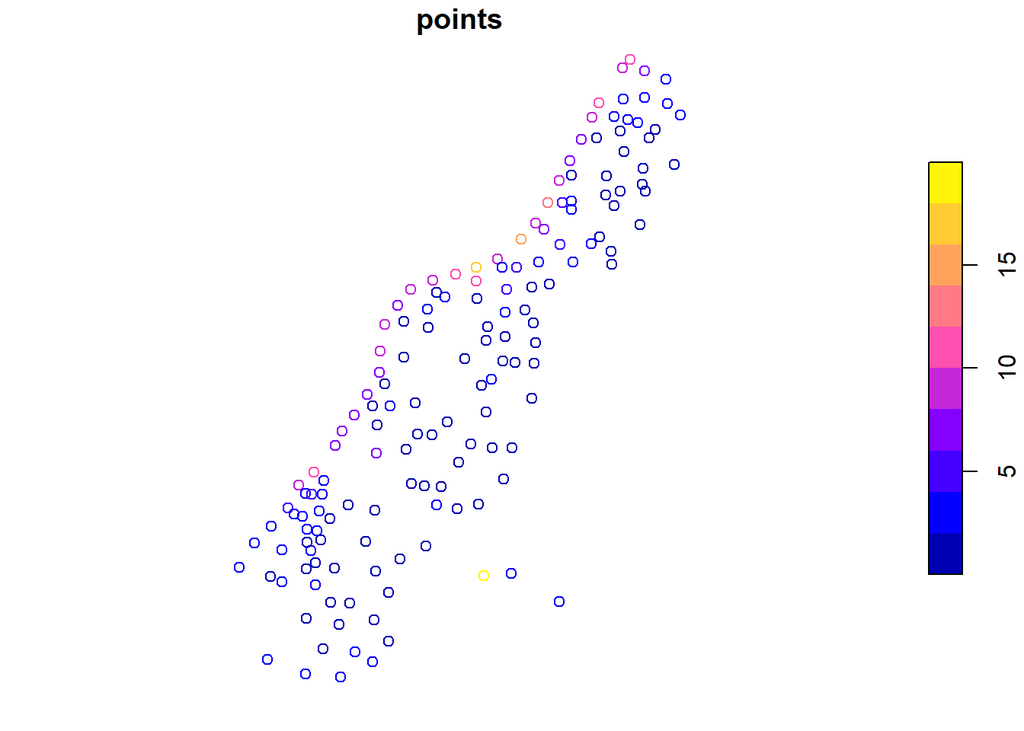

```r
plot(meuse[1], main = "points")
```

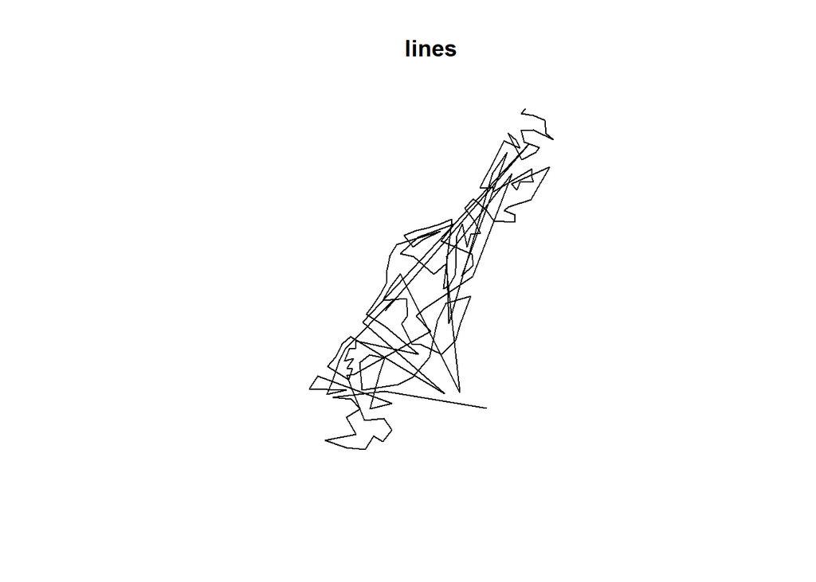

```r
line <- SpatialLines(list(Lines(list(Line(coord)), "line1")))
plot(line, main = "lines")
```

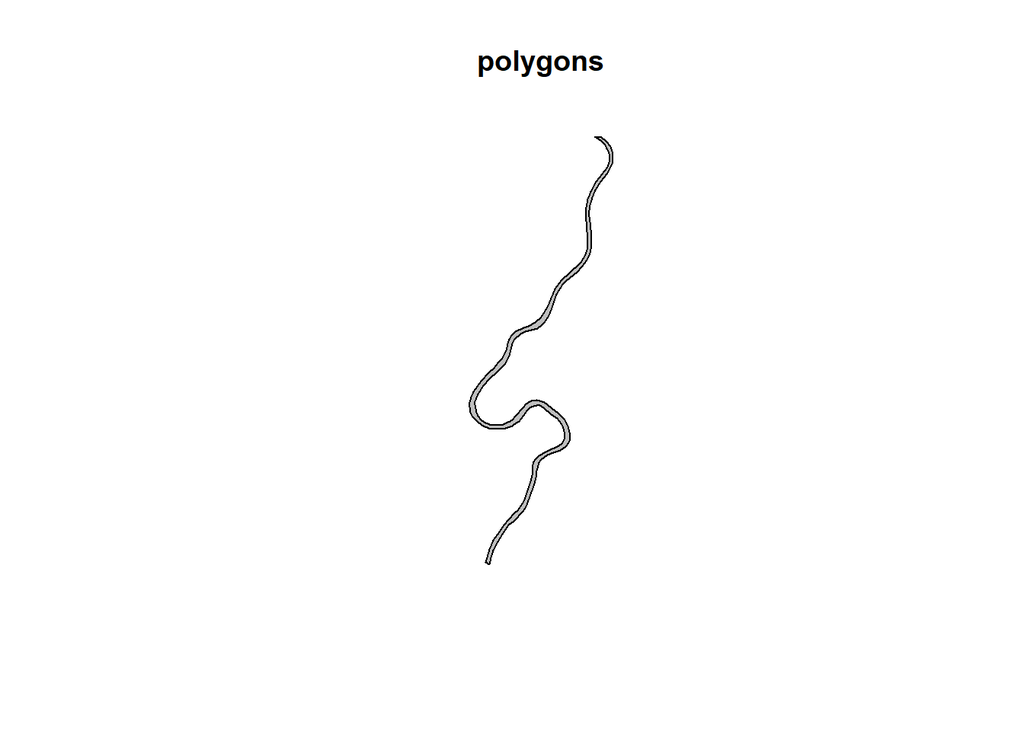

```r
data("meuse.riv")
meuse.lst <- list(Polygons(list(Polygon(meuse.riv)), "meuse.riv"))
meuse.pol <- SpatialPolygons(meuse.lst)

plot(meuse.pol, col = "grey", main ="polygons")
```

## Raster

Data spasial **raster** merepresentasikan permukaan bumi dalam bentuk **grid (pixel)**, di mana setiap sel memiliki nilai tertentu. Raster umumnya digunakan untuk data kontinu, seperti citra satelit, foto udara, model elevasi digital (DEM), nilai NDVI, suhu, atau curah hujan.

- Resolusi raster ditentukan oleh ukuran pixel, semakin kecil pixel maka detail yang ditampilkan semakin tinggi.
- Data raster cocok digunakan untuk analisis spasial berbasis permukaan, misalnya klasifikasi tutupan lahan atau interpolasi data geostatistik.

```r
pathraster <- system.file("ex/elev.tif", package = "terra")
r <- terra::rast(pathraster)
r
```

```
class       : SpatRaster
dimensions  : 90, 95, 1  (nrow, ncol, nlyr)
resolution  : 0.008333333, 0.008333333  (x, y)
extent      : 5.741667, 6.533333, 49.44167, 50.19167  (xmin, xmax, ymin, ymax)
coord. ref. : lon/lat WGS 84 (EPSG:4326)
source      : elev.tif
name        : elevation
min value   :       141
max value   :       547
```

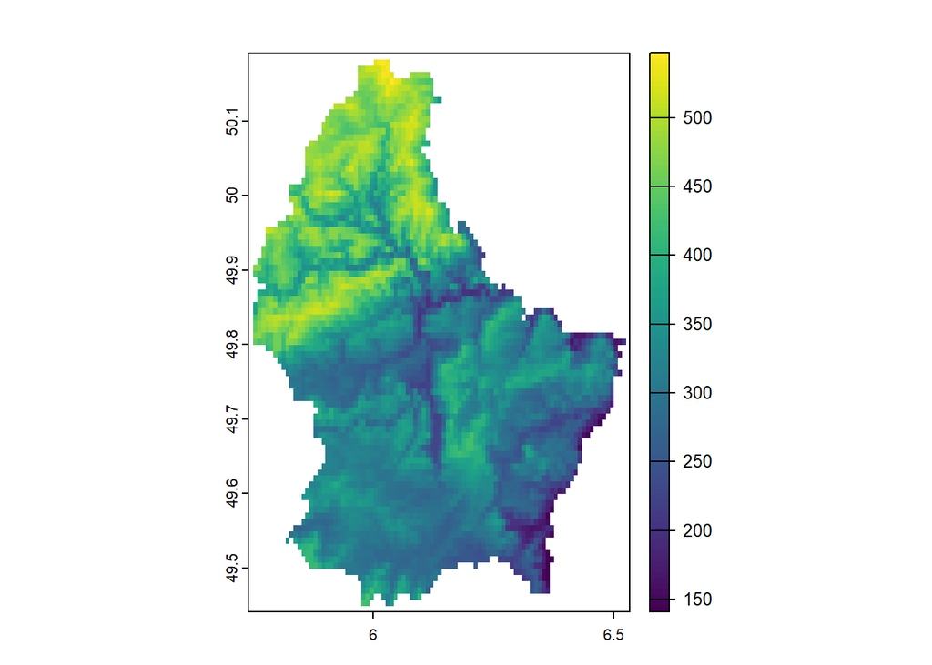

```r
plot(r)
```

# Coordinate Reference System

**Coordinate Reference System (CRS)** adalah sistem acuan yang digunakan untuk menentukan posisi titik di permukaan bumi. CRS menjelaskan bagaimana koordinat (x, y) atau (longitude, latitude) diproyeksikan ke dalam peta sehingga posisi geografis dapat direpresentasikan dengan benar. Tanpa CRS, angka koordinat tidak memiliki makna karena kita tidak tahu apakah satuannya derajat, meter, atau dari acuan mana dihitung.

## Kode EPSG

EPSG adalah standar internasional berupa **kode angka unik** yang diberikan untuk masing-masing CRS. Dengan EPSG, kita bisa menyebut suatu sistem koordinat tanpa perlu menuliskan definisi panjangnya. Misalnya:

- **EPSG:4326** → WGS84 (koordinat lintang–bujur, dipakai GPS).
- **EPSG:32748** → UTM Zona 48S berbasis WGS84 (Indonesia bagian barat daya, satuan meter).
- **EPSG:28992** → Amersfoort / RD New (Belanda).

Dengan mengetahui kode EPSG, pengguna GIS atau R bisa dengan mudah menetapkan atau mengubah CRS pada data spasial.

```r
st_crs("EPSG:4326")$Name
```

```
[1] "WGS 84"
```

```r
st_crs("EPSG:4326")$epsg
```

```
[1] 4326
```

## Transformasi CRS dengan `sf` dan `terra`

Dalam R, **transformasi CRS** dengan paket `sf` dan `terra` berarti mengubah sistem koordinat data spasial dari satu proyeksi ke proyeksi lain agar sesuai dengan kebutuhan analisis, pemetaan, atau integrasi data.

### Untuk data vektor

```r
library(sf)
pathshp <- system.file("shape/nc.shp", package = "sf")
map <- st_read(pathshp, quiet = TRUE)

st_crs(map) # cek CRS untuk tau sistem koordinat apa yang dipakai data aslinya
```

```
Coordinate Reference System:
  User input: NAD27
  wkt:
GEOGCRS["NAD27",
    DATUM["North American Datum 1927",
        ELLIPSOID["Clarke 1866",6378206.4,294.978698213898,
            LENGTHUNIT["metre",1]]],
    PRIMEM["Greenwich",0,
        ANGLEUNIT["degree",0.0174532925199433]],
    CS[ellipsoidal,2],
        AXIS["latitude",north,
            ORDER[1],
            ANGLEUNIT["degree",0.0174532925199433]],
        AXIS["longitude",east,
            ORDER[2],
            ANGLEUNIT["degree",0.0174532925199433]],
    ID["EPSG",4267]]
```

```r
# Transform CRS
map2 <- st_transform(map, crs = "EPSG:4326")
st_crs(map2)
```

```
Coordinate Reference System:
  User input: EPSG:4326
  wkt:
GEOGCRS["WGS 84",
    ENSEMBLE["World Geodetic System 1984 ensemble",
        MEMBER["World Geodetic System 1984 (Transit)"],
        MEMBER["World Geodetic System 1984 (G730)"],
        MEMBER["World Geodetic System 1984 (G873)"],
        MEMBER["World Geodetic System 1984 (G1150)"],
        MEMBER["World Geodetic System 1984 (G1674)"],
        MEMBER["World Geodetic System 1984 (G1762)"],
        MEMBER["World Geodetic System 1984 (G2139)"],
        MEMBER["World Geodetic System 1984 (G2296)"],
        ELLIPSOID["WGS 84",6378137,298.257223563,
            LENGTHUNIT["metre",1]],
        ENSEMBLEACCURACY[2.0]],
    PRIMEM["Greenwich",0,
        ANGLEUNIT["degree",0.0174532925199433]],
    CS[ellipsoidal,2],
        AXIS["geodetic latitude (Lat)",north,
            ORDER[1],
            ANGLEUNIT["degree",0.0174532925199433]],
        AXIS["geodetic longitude (Lon)",east,
            ORDER[2],
            ANGLEUNIT["degree",0.0174532925199433]],
    USAGE[
        SCOPE["Horizontal component of 3D system."],
        AREA["World."],
        BBOX[-90,-180,90,180]],
    ID["EPSG",4326]]
```

Mengubah (transformasi) CRS data `map` ke EPSG:4326 (WGS84)

### Untukk data Raster

```r
library(terra)
pathraster <- system.file("ex/elev.tif", package = "terra")
r <- rast(pathraster)
crs(r) # cek CRS dari raster untuk tau sistem koordinat aslinya.
```

```
[1] "GEOGCRS[\"WGS 84\",\n    ENSEMBLE[\"World Geodetic System 1984 ensemble\",\n        MEMBER[\"World Geodetic System 1984 (Transit)\"],\n        MEMBER[\"World Geodetic System 1984 (G730)\"],\n        MEMBER[\"World Geodetic System 1984 (G873)\"],\n        MEMBER[\"World Geodetic System 1984 (G11…
```

Raster ini menggunakan sistem koordinat WGS 84 (World Geodetic System 1984), sistem global yang paling umum dipakai.

```r
# Transform CRS
r2 <- terra::project(r, "EPSG:2169")
crs(r2)
```

```
[1] "PROJCRS[\"LUREF / Luxembourg TM\",\n    BASEGEOGCRS[\"LUREF\",\n        DATUM[\"Luxembourg Reference Frame\",\n            ELLIPSOID[\"International 1924\",6378388,297,\n                LENGTHUNIT[\"metre\",1]]],\n        PRIMEM[\"Greenwich\",0,\n            ANGLEUNIT[\"degree\",0.0174532925199…
```

# Impor dan Ekspor Data

## Import Data dari Paket Spasial di R

Kita dapat membaca objek `sf` dengan fungsi `st_read()`. Misalnya, di sini kita membaca shapefile `nc` yang berisi kabupaten-kabupaten di North Carolina, AS, beserta nama kabupaten, jumlah kelahiran, dan jumlah kematian bayi mendadak pada tahun 1974 dan 1979.

Pertama, kita menggunakan `system.file()` dengan parameter nama direktori `"shape/nc.shp"` dan nama paket `"sf"` untuk mengidentifikasi jalur shapefile.

```r
pathshp <- system.file("shape/nc.shp", package = "sf")
```

Kita dapat memeriksa direktori **shape** dan melihat bahwa direktori tersebut berisi berkas-berkas berikut yang sesuai dengan shapefile **North Carolina**:

```
shape
├── nc.shp
├── nc.shx
├── nc.dbf
└── nc.prj
```

Kemudian, kita membaca shapefile dengan `st_read()` memasukkan nama untuk membaca shapefile tersebut. Kita atur `quiet = TRUE` untuk menonaktifkan informasi tentang nama, driver, ukuran, dan referensi spasial.

```r
nc <- st_read(pathshp, quiet = TRUE)
class(nc)
```

```
[1] "sf"         "data.frame"
```

Selanjutnya kita dapat mengidentifikasi CRS yang digunakan pada data tersebut dengan fungsi `st_crs()`.

```r
st_crs(nc)
```

```
Coordinate Reference System:
  User input: NAD27
  wkt:
GEOGCRS["NAD27",
    DATUM["North American Datum 1927",
        ELLIPSOID["Clarke 1866",6378206.4,294.978698213898,
            LENGTHUNIT["metre",1]]],
    PRIMEM["Greenwich",0,
        ANGLEUNIT["degree",0.0174532925199433]],
    CS[ellipsoidal,2],
        AXIS["latitude",north,
            ORDER[1],
            ANGLEUNIT["degree",0.0174532925199433]],
        AXIS["longitude",east,
            ORDER[2],
            ANGLEUNIT["degree",0.0174532925199433]],
    ID["EPSG",4267]]
```

Data `nc` saat ini menggunakan **CRS EPSG:4267 (NAD27 – North American Datum 1927)**.

```r
head(nc, 5)
```

```
Simple feature collection with 5 features and 14 fields
Geometry type: MULTIPOLYGON
Dimension:     XY
Bounding box:  xmin: -81.74107 ymin: 36.07282 xmax: -75.77316 ymax: 36.58965
Geodetic CRS:  NAD27
   AREA PERIMETER CNTY_ CNTY_ID        NAME  FIPS FIPSNO CRESS_ID BIR74 SID74
1 0.114     1.442  1825    1825        Ashe 37009  37009        5  1091     1
2 0.061     1.231  1827    1827   Alleghany 37005  37005        3   487     0
3 0.143     1.630  1828    1828       Surry 37171  37171       86  3188     5
4 0.070     2.968  1831    1831   Currituck 37053  37053       27   508     1
5 0.153     2.206  1832    1832 Northampton 37131  37131       66  1421     9
  NWBIR74 BIR79 SID79 NWBIR79                       geometry
1      10  1364     0      19 MULTIPOLYGON (((-81.47276 3...
2      10   542     3      12 MULTIPOLYGON (((-81.23989 3...
3     208  3616     6     260 MULTIPOLYGON (((-80.45634 3...
4     123   830     2     145 MULTIPOLYGON (((-76.00897 3...
5    1066  1606     3    1197 MULTIPOLYGON (((-77.21767 3...
```

Kolom geometry mengimpan informasi terkait dengan ukuran geometri pada suatu objek sf, contohnya titik, garis, poligon, yang bersesuaian dengan baris pada atribut data pada kolom-kolom yang berada di depannya.

Kita dapat memplot informasi objek sf sebagai berikut:

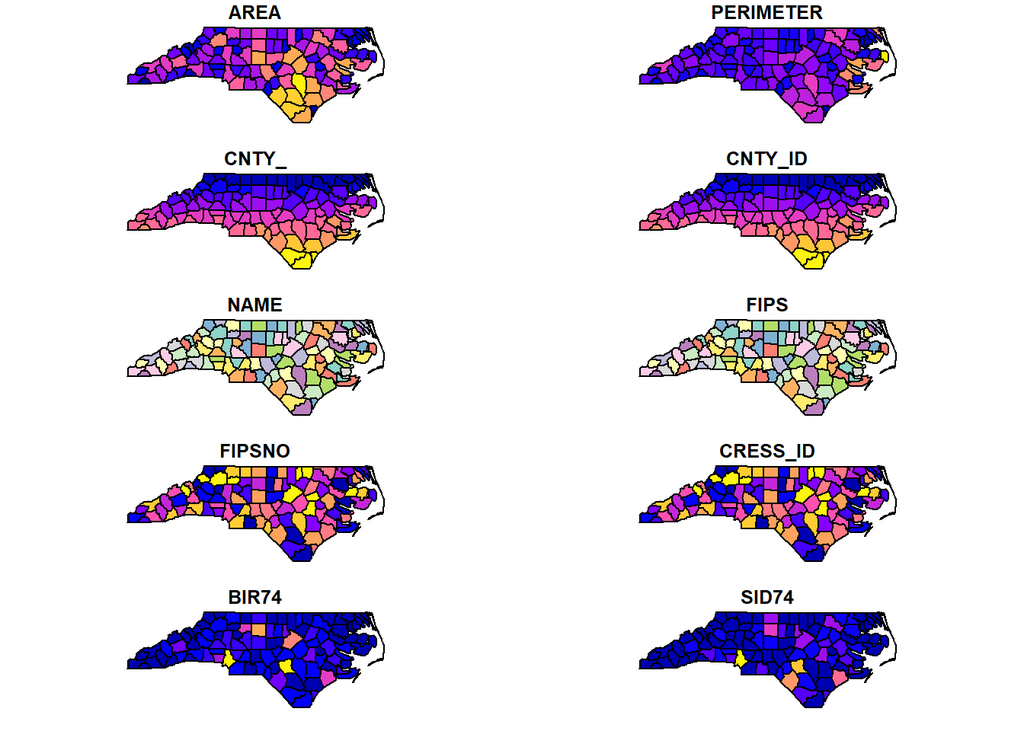

```r
plot(nc)
```

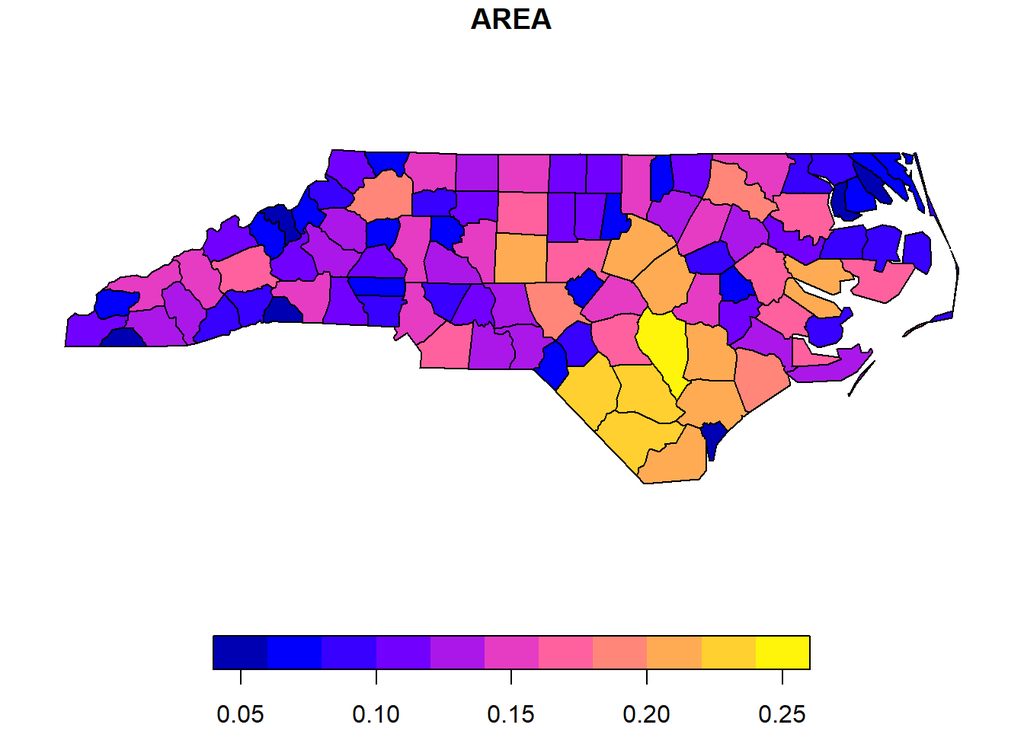

```r
plot(nc[1]) #plot salah satu atribut
```

## Impor Data Eksternal

Data dengan format shapefile akan memerlukan beberapa file dengan nama yang sama, di antaranya adalah file dengan format .shp, .shx, .dbf, .prj, dsb. Sehingga kita perlu menyimpan seluruh file tersebut dalam satu folder. Folder tersebut selanjutnya disebut sebagai dsn, sedangkan nama file disebut sebagai layer. Selanjutnya, impor data dapat dilakukan dengan fungsi seperti bawah ini.

Silahkan mengunduh data yang digunakan pada ilustrasi ini pada link berikut [download disini](https://www.dropbox.com/scl/fi/raxmkethst86yigkpvl9i/cape_peninsula.zip?rlkey=67wdrcowqu0h3qyngtqet4kga&e=1&dl=0)

```r
veg<-st_read(dsn="cape_peninsula/veg", layer="Vegetation_Indigenous")
```

```r
class(veg)
```

```
[1] "sf"         "data.frame"
```